# Lab Assignment One: Exploring Table Data

Austin Howard  
Dr. Eric Larson  
CS 7324 401 - Machine Learning In Python  
2025-09-14

## 1. Business Understanding

### 1.1 Dataset

**Dataset:** Clickstream Data for Online Shopping  
**Source:** UCI Machine Learning Repository  
**URL:** https://archive.ics.uci.edu/dataset/553/clickstream+data+for+online+shopping

### 1.3 Collection

*Clickstream Data for Online Shopping* was collected from real-world e-commerce session logs during the months of April through August in 2008. Each session is given a session ID and recorded within are the sequence of clicks a visitor made during their time on the website. Data was extracted directly from web server logs, giving us actual consumer browsing behavior.

### 1.4 Purpose

E-Commerce has been a disruptive industry when compared to traditional brick and mortar retail establishments, especially since the Covid-19 outbreak of 2020. In this modern retail landscape, businesses and/or marketing teams want to know what factors influence whether a visitor engages with a product to target their ads effectively. This dataset will allow us to correlate a group's interest in a specific product or group of products.

### 1.5 Prediction Task

Let's say we are a boutique selling high-end products and want to expand operations into other countries. In order to do so, it would behoove you to investigate which countries have citizens with the deepest pockets, or perhaps which product they empty their pockets for. So, let's ask the question:

**What product can I create to maximize quality, and where should it be sold?**

This can be sought out through country of origin, product category, color, and other relevant features in the dataset. Answering this question help our boutique reveal how customer demographics and browsing behavior impact their willingness to purchase premium items.

### 1.6 Accuracy

For predictions to be useful to businesses, the model needs to achieve a reasonably high level of accuracy. An high enough accuracy would give us the confidence needed to apply the model in decision-making contexts. We could in-turn tailor promotions to users who are most likely to purchase our high-value items. Predictions with lower accuracy may lead our marketing strategy astray, leading to poor returns on advertising expenditures.

The threshold of accuracy is defined on a case by case basis, but using inferences drawn from this data should never *decrease* the amount of clicks on a website. That is to say, on the whole, interpretations must drive clicks surpassing the status quo.

## 2. Data Understanding

### 2.1 Instantiation

To begin, when loading the dataset, one must change the CSV seperator to semi-colon as opposed to the default value (which is a comma, and in this case returned only one column with a list of attributes).

```python
import pandas as pd
import numpy as np
import warnings

# Suppress filter warnings
warnings.filterwarnings("ignore")

# Load the dataset (which is seperated by semi-colon)
df = pd.read_csv("e-shop clothing 2008.csv", sep=";")

# Display first 5 rows
df.head()
```

|  | year | month | day | order | country | session ID | page 1 (main category) | page 2 (clothing model) | colour | location | model photography | price | price 2 | page |
| --- | --- | --- | --- | --- | --- | --- | --- | --- | --- | --- | --- | --- | --- | --- |
| 0 | 2008 | 4 | 1 | 1 | 29 | 1 | 1 | A13 | 1 | 5 | 1 | 28 | 2 | 1 |
| 1 | 2008 | 4 | 1 | 2 | 29 | 1 | 1 | A16 | 1 | 6 | 1 | 33 | 2 | 1 |
| 2 | 2008 | 4 | 1 | 3 | 29 | 1 | 2 | B4 | 10 | 2 | 1 | 52 | 1 | 1 |
| 3 | 2008 | 4 | 1 | 4 | 29 | 1 | 2 | B17 | 6 | 6 | 2 | 38 | 2 | 1 |
| 4 | 2008 | 4 | 1 | 5 | 29 | 1 | 2 | B8 | 4 | 3 | 2 | 52 | 1 | 1 |

```python
# List the data types
print(df.info())
```

```
<class 'pandas.core.frame.DataFrame'>
RangeIndex: 165474 entries, 0 to 165473
Data columns (total 14 columns):
 #   Column                   Non-Null Count   Dtype
---  ------                   --------------   -----
 0   year                     165474 non-null  int64
 1   month                    165474 non-null  int64
 2   day                      165474 non-null  int64
 3   order                    165474 non-null  int64
 4   country                  165474 non-null  int64
 5   session ID               165474 non-null  int64
 6   page 1 (main category)   165474 non-null  int64
 7   page 2 (clothing model)  165474 non-null  object
 8   colour                   165474 non-null  int64
 9   location                 165474 non-null  int64
 10  model photography        165474 non-null  int64
 11  price                    165474 non-null  int64
 12  price 2                  165474 non-null  int64
 13  page                     165474 non-null  int64
dtypes: int64(13), object(1)
memory usage: 17.7+ MB
None
```

We can further analyze this data by viewing the data description. We can see that, by looking at the minimum values, there are no 0 values in the dataset. It's safe to conclude that there are no missing values contained within. Given what we know about the time the survey was taken (2008, April through August), the values in the "year" and "month" columns align perfectly, showing a range of only 2008 (which also had a standard deviation of 0) in the months specified. Further, the averages in "month" — which indicates May, and "day" — which shows an average in the middle of a normal calendar month, we can see that the data is aligned with what we would expect.

```python
# find the data summary
df.describe()
```

|  | year | month | day | order | country | session ID | page 1 (main category) | colour | location | model photography | price | price 2 | page |
| --- | --- | --- | --- | --- | --- | --- | --- | --- | --- | --- | --- | --- | --- |
| count | 165474.0 | 165474.000000 | 165474.000000 | 165474.000000 | 165474.000000 | 165474.000000 | 165474.000000 | 165474.000000 | 165474.000000 | 165474.000000 | 165474.000000 | 165474.000000 | 165474.000000 |
| mean | 2008.0 | 5.585887 | 14.524554 | 9.817476 | 26.952621 | 12058.417056 | 2.400842 | 6.227655 | 3.258198 | 1.260071 | 43.802507 | 1.488167 | 1.710166 |
| std | 0.0 | 1.328160 | 8.830374 | 13.478411 | 7.150691 | 7008.418903 | 1.144420 | 4.235606 | 1.713206 | 0.438674 | 12.548131 | 0.499861 | 0.982412 |
| min | 2008.0 | 4.000000 | 1.000000 | 1.000000 | 1.000000 | 1.000000 | 1.000000 | 1.000000 | 1.000000 | 1.000000 | 18.000000 | 1.000000 | 1.000000 |
| 25% | 2008.0 | 4.000000 | 7.000000 | 2.000000 | 29.000000 | 5931.000000 | 1.000000 | 3.000000 | 2.000000 | 1.000000 | 33.000000 | 1.000000 | 1.000000 |
| 50% | 2008.0 | 5.000000 | 14.000000 | 6.000000 | 29.000000 | 11967.500000 | 2.000000 | 4.000000 | 3.000000 | 1.000000 | 43.000000 | 1.000000 | 1.000000 |
| 75% | 2008.0 | 7.000000 | 22.000000 | 12.000000 | 29.000000 | 18219.000000 | 3.000000 | 9.000000 | 5.000000 | 2.000000 | 52.000000 | 2.000000 | 2.000000 |
| max | 2008.0 | 8.000000 | 31.000000 | 195.000000 | 47.000000 | 24026.000000 | 4.000000 | 14.000000 | 6.000000 | 2.000000 | 82.000000 | 2.000000 | 5.000000 |

### 2.2 Data Quality

Following instantiation, care must be taken to ensure that the data can be used in a way that makes sense for our visualization (and subsequent analysis) of the features contained in the dataframe.

First, we investigated whether or not there were any duplicates found within our dataset. Thankfully, there did not appear to be any. This makes sense given that the order & session ID combine to make a sort of unique ID. As long as the combination of those two combined values are not duplicated, then it would imply that no duplicates exist.

```python
# Find instances of duplicated data
idx = df.duplicated()

# Display the number of duplicates found within
len(df[idx])
```

```
0
```

The following datatypes were modified by mapping the integer value to a descriptive label and made categorical:

- **Country** - The country of the session based on IP address
- **Page 1** - The Main Category of what is being looked at
- **Color** - The color of the product
- **Location** - The location on screen
- **Model Photography** - The type of photograph captured of the modeland used for the product

```python
# Map numeric codes to the country names, make categorical
country_map = {
    1:"Australia", 2:"Austria", 3:"Belgium", 4:"British Virgin Islands", 5:"Cayman Islands",
    6:"Christmas Island", 7:"Croatia", 8:"Cyprus", 9:"Czech Republic", 10:"Denmark",
    11:"Estonia", 12:"unidentified", 13:"Faroe Islands", 14:"Finland", 15:"France",
    16:"Germany", 17:"Greece", 18:"Hungary", 19:"Iceland", 20:"India",
    21:"Ireland", 22:"Italy", 23:"Latvia", 24:"Lithuania", 25:"Luxembourg",
    26:"Mexico", 27:"Netherlands", 28:"Norway", 29:"Poland", 30:"Portugal",
    31:"Romania", 32:"Russia", 33:"San Marino", 34:"Slovakia", 35:"Slovenia",
    36:"Spain", 37:"Sweden", 38:"Switzerland", 39:"Ukraine", 40:"United Arab Emirates",
    41:"United Kingdom", 42:"USA", 43:"biz (*.biz)", 44:"com (*.com)", 45:"int (*.int)",
    46:"net (*.net)", 47:"org (*.org)"
}
df["country"] = pd.to_numeric(df["country"], errors="coerce").map(country_map).astype("category")

# Map out page 1 codes to clothing type, make categorical
page1_map = {1:"trousers", 2:"skirts", 3:"blouses", 4:"sale"}
df["page 1 (main category)"] = (
    pd.to_numeric(df["page 1 (main category)"], errors="coerce")
      .map(page1_map)
      .astype("category")
)

# Map colours to descriptive labels, make categorical
colour_map = {
    1:"beige", 2:"black", 3:"blue", 4:"brown", 5:"burgundy", 6:"gray", 7:"green",
    8:"navy blue", 9:"of many colors", 10:"olive", 11:"pink", 12:"red", 13:"violet", 14:"white"
}
df["colour"] = pd.to_numeric(df["colour"], errors="coerce").map(colour_map).astype("category")

# Map location to descriptive labels, make categorical
location_map = {
    1:"top_left", 2:"top_middle", 3:"top_right",
    4:"bottom_left", 5:"bottom_middle", 6:"bottom_right"
}
df["location"] = pd.to_numeric(df["location"], errors="coerce").map(location_map).astype("category")

# Map model photography to descriptive labels, make categorical
model_map = {1:"en face", 2:"profile"}
df["model photography"] = pd.to_numeric(df["model photography"], errors="coerce").map(model_map).astype("category")

# Display first 5 rows
df.head()
```

|  | year | month | day | order | country | session ID | page 1 (main category) | page 2 (clothing model) | colour | location | model photography | price | price 2 | page |
| --- | --- | --- | --- | --- | --- | --- | --- | --- | --- | --- | --- | --- | --- | --- |
| 0 | 2008 | 4 | 1 | 1 | Poland | 1 | trousers | A13 | beige | bottom_middle | en face | 28 | 2 | 1 |
| 1 | 2008 | 4 | 1 | 2 | Poland | 1 | trousers | A16 | beige | bottom_right | en face | 33 | 2 | 1 |
| 2 | 2008 | 4 | 1 | 3 | Poland | 1 | skirts | B4 | olive | top_middle | en face | 52 | 1 | 1 |
| 3 | 2008 | 4 | 1 | 4 | Poland | 1 | skirts | B17 | gray | bottom_right | profile | 38 | 2 | 1 |
| 4 | 2008 | 4 | 1 | 5 | Poland | 1 | skirts | B8 | brown | top_right | profile | 52 | 1 | 1 |

After doing so, **Year/Month/Day** was converted to a single **Date** feature to show the date the session occurred, grouping three columns into one.Aditionally, **Price 2** was converted to **Premium Pricing** for clearer meaning and to change the datatype to boolean to indicate whether or not it was listed at an above average price from others in its category.

```python
# Combine year, month, day into a single datetime column
df["date"] = pd.to_datetime(df[["year", "month", "day"]])

# Create new column, Convert 'price 2' to boolean
df["premium pricing"] = df["price 2"].map({1: True, 2: False})

# Group the new features into a new table for display, showing first 5 rows
df_display = df[["date", "order","country","session ID", "page 1 (main category)", "page 2 (clothing model)", "colour","location","model photography","price","premium pricing"]]
df_display.head()
```

|  | date | order | country | session ID | page 1 (main category) | page 2 (clothing model) | colour | location | model photography | price | premium pricing |
| --- | --- | --- | --- | --- | --- | --- | --- | --- | --- | --- | --- |
| 0 | 2008-04-01 | 1 | Poland | 1 | trousers | A13 | beige | bottom_middle | en face | 28 | False |
| 1 | 2008-04-01 | 2 | Poland | 1 | trousers | A16 | beige | bottom_right | en face | 33 | False |
| 2 | 2008-04-01 | 3 | Poland | 1 | skirts | B4 | olive | top_middle | en face | 52 | True |
| 3 | 2008-04-01 | 4 | Poland | 1 | skirts | B17 | gray | bottom_right | profile | 38 | False |
| 4 | 2008-04-01 | 5 | Poland | 1 | skirts | B8 | brown | top_right | profile | 52 | True |

Nothing else was touched initially, and the unchanged features are described as follows:

- **Session ID** - The instance by which a user has spent in a website during a span of time.
- **Order** - The number of clicks in the session at present, a sequential ordering of the clicks from product to product
- **Price** - The cost in USD
- **Page** - The page number of the site being visited

## 3. Data Visualization

### 3.1 Data Exploration

```python
import matplotlib.pyplot as plt
import seaborn as sns

# Suppress deprecation warnings
warnings.simplefilter('ignore', DeprecationWarning)
```

#### 3.1.1 Distribution of Product Prices

We can examine the overall distribution of product prices to understand their dynamic range and spread.

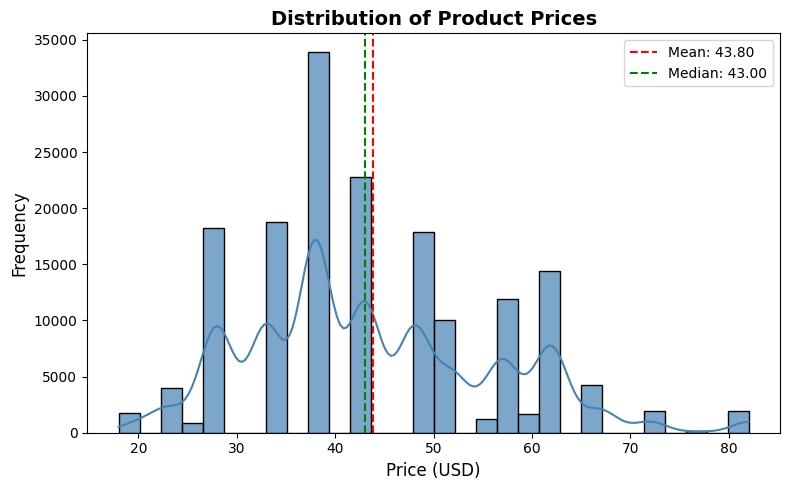

```python
plt.figure(figsize=(8,5))

# Use fewer bins for smoother appearance
sns.histplot(df["price"], bins=30, kde=True, color="steelblue", edgecolor="black", alpha=0.7, kde_kws={"bw_adjust": 1.5})

# Add mean and median lines
plt.axvline(df["price"].mean(), color='red', linestyle='dashed', linewidth=1.5, label=f"Mean: {df['price'].mean():.2f}")
plt.axvline(df["price"].median(), color='green', linestyle='dashed', linewidth=1.5, label=f"Median: {df['price'].median():.2f}")

# Titles and labels
plt.title("Distribution of Product Prices", fontsize=14, fontweight="bold")
plt.xlabel("Price (USD)", fontsize=12)
plt.ylabel("Frequency", fontsize=12)

# Display histogram
plt.legend()
plt.tight_layout()
plt.show()
```

#### 3.1.2 Percentage of Premium vs. Non-Premium Products by Category

Next, it's important to understand the balance of our target variable: whether products are premium-priced or not. We should group these by category to see which product to offer.

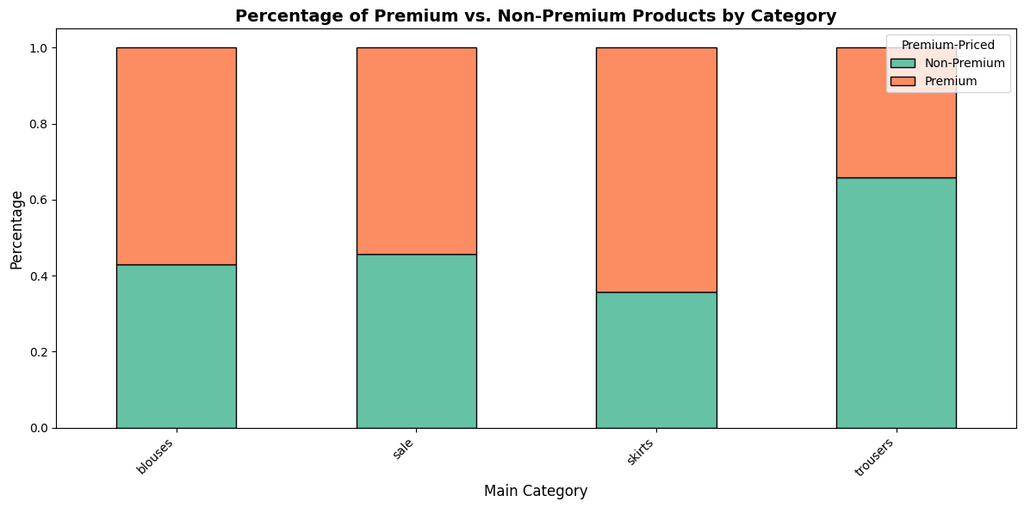

```python
plt.figure(figsize=(12,6))

# Calculate percentages by category
counts = df.groupby("page 1 (main category)")["premium pricing"].value_counts(normalize=True).unstack().fillna(0)

# Create stacked bar chart
counts.plot(
    kind="bar",
    stacked=True,
    color=["#66c2a5", "#fc8d62"],   # Non-Premium, Premium
    edgecolor="black",
    figsize=(12,6)
)

# Display the stacked bar chart
plt.title("Percentage of Premium vs. Non-Premium Products by Category", fontsize=14, fontweight="bold")
plt.xlabel("Main Category", fontsize=12)
plt.ylabel("Percentage", fontsize=12)
plt.xticks(rotation=45, ha="right")
plt.legend(title="Premium-Priced", labels=["Non-Premium", "Premium"])
plt.tight_layout()
plt.show()
```

The count plot reveals that non-premium products are more common than expected at first glance. The trousers in this dataset are typically at or below average price levels, making it an unlikely candidate for generating interest. On the other hamd, blouses and especially skirts have proved that they can generate more clicks, without needing to be sold at a lower price.

#### 3.1.3 Price Distribution by Product Category

Now we'll compare the distribution of product prices across different clothing categories. This will enable us to show which categories have higher or lower price ranges. A violin chart is useful here, as it will reveal both the spread of the data (similar to a boxplot) as well as its density (like a KDE). This data will help us identify whether premium pricing is concentrated to specific categories, helping us identify whether to focus effrts on skirts or trousers.

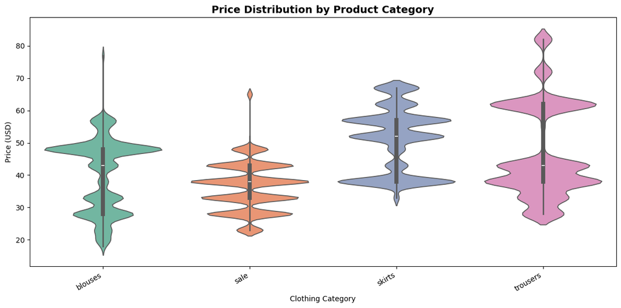

```python
# Data for plot
CATEGORY_COL = "page 1 (main category)"
PRICE_COL = "price"

# Set size of plot
plt.figure(figsize=(12, 6))

# Create violin plot
sns.violinplot(
    data=df,
    x=CATEGORY_COL,
    y=PRICE_COL,
    inner="box",        # Makes a mini boxplot inside the violin
    scale="width",      # Makes violins comparable across categories
    palette="Set2"      # Sets the color palette
)

# Plot Settings
plt.title("Price Distribution by Product Category", fontsize=14, weight="bold")
plt.xlabel("Clothing Category")
plt.ylabel("Price (USD)")
plt.xticks(rotation=30, ha="right")

# Display the plat
plt.tight_layout()
plt.show()
```

From this, we can see that skirts and trousers tend to be consistently higher in price. Categories such as blouses and trousers tend to have a wide variance, meaning that both budget-friendly andn luxury items withihn that category draw attention. Blouses in particular have an incredibly long tail, indicating that it contains outliers in its luxury offerings.

#### 3.1.4 Country Distribution

Next, we will visualize the country frequencies contained within the dataset, and order them by highest frequncy. This will tell us which markets are most represented in the dataset and whether or not the data is concentrated to a specific region or spread across the globe. This is important, because the culture of a particular nation within the dataset might have very different spending habits than another. Factors such as GDP, taxation, and politics have a major say in aa group's buying habits.

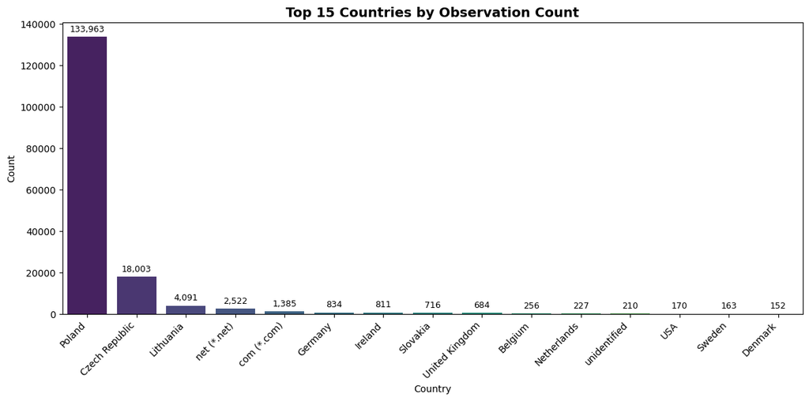

```python
# Data for the plot
COUNTRY_COL = "country"

# Count rows by country
country_counts = df[COUNTRY_COL].value_counts().reset_index()
country_counts.columns = ["country", "count"]

# Plot top N countries
TOP_N = 15
top_counts = country_counts.head(TOP_N)

# Create Bar plot
plt.figure(figsize=(12, 6))
ax = sns.barplot(
    data=top_counts,
    x="country",
    y="count",
    order=top_counts["country"],   # ensures correct ordering
    palette="viridis"
)

# Bar plot settings
plt.title(f"Top {TOP_N} Countries by Observation Count", fontsize=14, weight="bold")
plt.xlabel("Country")
plt.ylabel("Count")
plt.xticks(rotation=45, ha="right")

# Add labels above bars
for p in ax.patches:
    ax.annotate(
        f"{int(p.get_height()):,}",            # formatted number
        (p.get_x() + p.get_width() / 2., p.get_height()),  # position
        ha="center", va="bottom", fontsize=9, xytext=(0, 3), textcoords="offset points"
    )

# Display Bar chart
plt.tight_layout()
plt.show()
```

To focus in on where we can be most effective, the data was limited to focus on the top 15 countries within it. This shines a spotlight on the fact that the dataset contains mostly regional data, confined mostly to central Europe. Poland, in particular, is overrepresented. Trying to focus efforts in the Americas, Asia, Africa, or Oceania will prove more difficult.

#### 3.1.5 Order Frequency Distribution

We need to get a deeper understanding of how many products users typically interact with in a session. This is indicated in our dataset by the "order" feature. This will help reveal whether sessions are usually short (clicking through only a few items) or long (many items being clicked on in a session). Further analysis of this preliminary data could reveal what products in particular are generating — *and retaining* — consumer interest.

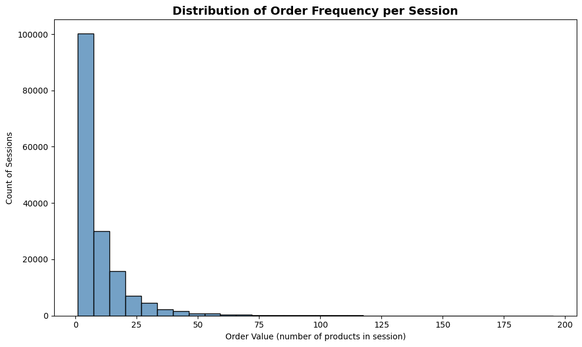

```python
ORDER_COL = "order"

plt.figure(figsize=(10, 6))

sns.histplot(
    data=df,
    x=ORDER_COL,
    bins=30,          # adjust number of bins for resolution
    kde=False,        # keep it simple (counts only)
    color="steelblue"
)

plt.title("Distribution of Order Frequency per Session", fontsize=14, weight="bold")
plt.xlabel("Order Value (number of products in session)")
plt.ylabel("Count of Sessions")

plt.tight_layout()
plt.show()
```

Predictable it may be, most sessions contained only 1-5 orders. The number of sessions tapers off dramatically as order values increase, which is expected behavior. While extreme values exist, it should be investigated whether or not these identify normal shopping behavior (or perhaps is it bots generating this traffic?). Determining normal, human shopping behavior in a high order value will allow us to dileneate casual users, captivated users, and bots.

### 3.2 Asking Deeper Questions

#### 3.2.1 Do prices/orders fluctuate across time?

To explore seasonal buying patterns, we plot the average product price and the total number of orders over time.  
If significant fluctuations are observed, this could indicate seasonal demand or pricing strategies, which are critical for planning promotions and identifying when to push premium products.

```python
# Ensure datetime is present
df["date"] = pd.to_datetime(df[["year", "month", "day"]])

# Aggregate by date
time_summary = df.groupby("date").agg(
    avg_price=("price", "mean"),
    total_orders=("order", "sum")
).reset_index()

# Compute correlation with pandas
corr = time_summary["avg_price"].corr(time_summary["total_orders"])
```

We visualize orders (bars) alongside average price (line) over time, and also compute the Pearson correlation between them.  
This correlation value is displayed on the chart to quantify how strongly orders and prices move together.

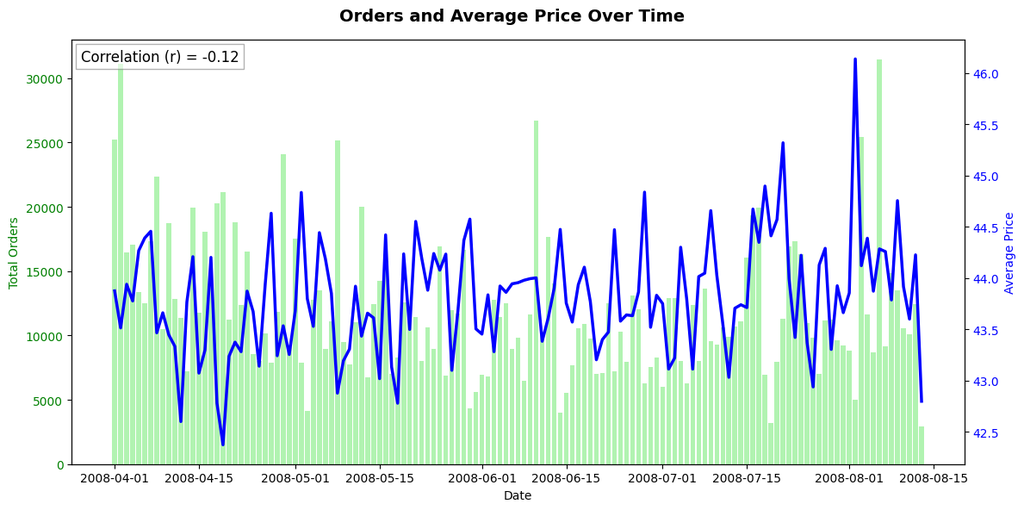

```python
# Create figure
fig, ax1 = plt.subplots(figsize=(12, 6))

# Create a bar chart for Orders
ax1.bar(time_summary["date"], time_summary["total_orders"],
        color="lightgreen", alpha=0.7, label="Total Orders")
ax1.set_xlabel("Date")
ax1.set_ylabel("Total Orders", color="green")
ax1.tick_params(axis="y", labelcolor="green")

# Create a line chart for Average Price
ax2 = ax1.twinx()
ax2.plot(time_summary["date"], time_summary["avg_price"],
         color="blue", linewidth=2.5, label="Average Price")
ax2.set_ylabel("Average Price", color="blue")
ax2.tick_params(axis="y", labelcolor="blue")

# Title and formatting
fig.suptitle("Orders and Average Price Over Time", fontsize=14, weight="bold")

# Label correlation on the plot
plt.text(
    0.01, 0.95, f"Correlation (r) = {corr:.2f}",
    transform=ax1.transAxes, fontsize=12, color="black",
    bbox=dict(facecolor="white", alpha=0.6, edgecolor="gray")
)

fig.tight_layout()
plt.show()
```

#### 3.2.2 Do certain categories dominate in certain countries?

To explore whether product preferences vary by geography, we calculate the frequency of product categories across countries.

We construct a pivot table of category counts by country and visualize it as a heatmap. To avoid distortion from Poland’s overrepresentation in the dataset, we convert raw counts into ratios (row-wise normalization). This ensures that each country’s row reflects the *distribution of categories within that country*, not just overall volume. This provides a clearer basis for targeted product and market strategy.

```python
CATEGORY_COL = "page 1 (main category)"
COUNTRY_COL = "country"

# Pivot table: counts of category occurrences per country
category_country = pd.pivot_table(
    df,
    values="session ID",  # any column works for counting
    index=COUNTRY_COL,
    columns=CATEGORY_COL,
    aggfunc="count",
    fill_value=0
)

# Convert to ratios (row-wise normalization)
category_country_ratio = category_country.div(category_country.sum(axis=1), axis=0)

# (Optional) Limit to top N countries by volume for readability
TOP_N = 15
top_countries = df[COUNTRY_COL].value_counts().head(TOP_N).index
category_country_ratio = category_country_ratio.loc[category_country_ratio.index.isin(top_countries)]
```

Strong concentrations in the heatmap reveal where certain categories are most popular. This helps us guide our marketing strategy and product placement.

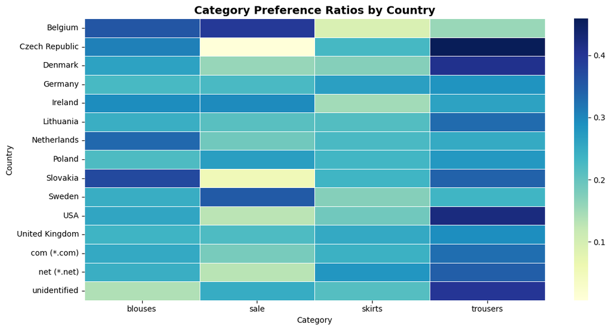

```python
# Plot heatmap
plt.figure(figsize=(12, 6))
sns.heatmap(category_country_ratio, cmap="YlGnBu", linewidths=0.5)

plt.title("Category Preference Ratios by Country", fontsize=14, weight="bold")
plt.xlabel("Category")
plt.ylabel("Country")
plt.tight_layout()
plt.show()
```

From this visualization, we can intuit that trousers dominate the preferences of many, particularly the Czech Republic and the USA. It's a safe bet that releasing a new brand of trousers in the Czechia will generate interest if priced correctly (recall that the Czech Republic is among the most well-represented nations in this dataset).

Another extrapolation is to find countries with a wide variety of interestes (e.g. Lithuania). In these instances, product interest will be, at the very least, average among other categories. This means a lower-risk (and lower-reward) product introduction.

#### 3.2.3 Do colors of trousers in the Czech Republic correlate with price and popularity?

To maximize potential revenue, we've opted to bring the spotlight to the Czech Republic and the types of trousers that captivates its interest. As an anecdote, Chinos are increasing in popularity due to their affordability and availbility in many colors. People just don't seem to need the rugged capabilities of jeans anymore (or, they aren't willing to pay a premium for it). Does this ring true for Czechia?

```python
from matplotlib import colors as mcolors

# Features
CATEGORY_COL = "page 1 (main category)"
COUNTRY_COL  = "country"
COLOUR_COL   = "colour"       # British spelling is used in dataset
PRICE_COL    = "price"
SESSION_COL  = "session ID"

# Filter featureset
mask_country  = df[COUNTRY_COL].astype(str).str.strip().str.casefold().eq("czech republic")
mask_category = df[CATEGORY_COL].astype(str).str.strip().str.casefold().eq("trousers")
d = df[mask_country & mask_category].copy()

# Aggregate by colour
agg = (
    d.groupby(COLOUR_COL, dropna=True)
     .agg(
         avg_price=(PRICE_COL, "mean"),
         unique_sessions=(SESSION_COL, "nunique"),
         n_rows=(PRICE_COL, "size")       # optional: total rows available per colour
     )
     .reset_index()
)
# Manual color lookup table
custom_map = {
    "navy blue": "navy",
    "grey": "gray",
    "burgundy": "#800020",
    "of many colors": "#9e9e9e"
}
# Color mapping function
def to_mpl_colour(name: str) -> str:
    key = str(name).strip().lower()
    if key in custom_map:
        return custom_map[key]
    return key if key in mcolors.CSS4_COLORS else "#9e9e9e"
```

To examine whether trouser color influences both "pricing" *and* "populatrity", we plot each colour as a point where:

- **X-axis** = average price of that colour,
- **Y-axis** = unique session IDs (popularity),
- **Point colour** = the actual trouser colour,
- **Dashed line** = regression trend,
- **r-value** = Pearson correlation between average price and unique sessions.
- **Bubble size** = Data volume per Point colour

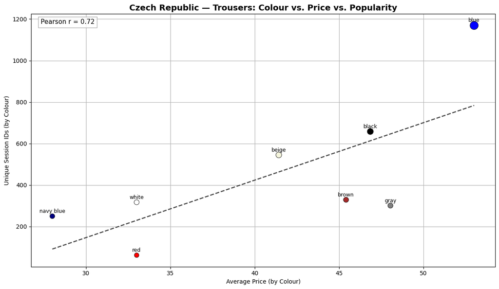

```python
# Apply mapping function
agg["mpl_color"] = agg[COLOUR_COL].astype(str).map(to_mpl_colour)

# Calculate Pearson correlation
r = agg["avg_price"].corr(agg["unique_sessions"])

# Scatter (one point per colour)
fig, ax = plt.subplots(figsize=(12, 7))

# Bubble size: proportional to data volume per colour (cap for readability)
sizes = 60 + 140 * (agg["n_rows"] / agg["n_rows"].max())

# Place bubbles on scatter plot
sc = ax.scatter(
    agg["avg_price"], agg["unique_sessions"],
    s=sizes,
    c=agg["mpl_color"],
    edgecolor="black",
    linewidth=0.6
)

# Label each point with its colour text
for _, row in agg.iterrows():
    ax.annotate(
        row[COLOUR_COL],
        (row["avg_price"], row["unique_sessions"]),
        textcoords="offset points",
        xytext=(0, 6),
        ha="center",
        fontsize=9
    )

# Regression line
x = agg["avg_price"].to_numpy()
y = agg["unique_sessions"].to_numpy()

# Keep only finite values
finite = np.isfinite(x) & np.isfinite(y)
x2, y2 = x[finite], y[finite]

# Add regression trend line
if len(x2) >= 2 and np.var(x2) > 0:
    x_mean = x2.mean()
    y_mean = y2.mean()
    # slope m = Cov(x,y) / Var(x)
    m = ((x2 - x_mean) * (y2 - y_mean)).sum() / ((x2 - x_mean) ** 2).sum()
    b = y_mean - m * x_mean

    xs = np.linspace(x2.min(), x2.max(), 100)
    ax.plot(xs, m * xs + b, linestyle="--", linewidth=1.8, color="#444444", label="Trend")

# Label Axes & title
ax.set_xlabel("Average Price (by Colour)")
ax.set_ylabel("Unique Session IDs (by Colour)")
ax.set_title("Czech Republic — Trousers: Colour vs. Price vs. Popularity", fontsize=14, fontweight="bold")

# Correlation annotation box
ax.text(
    0.02, 0.98,
    f"Pearson r = {r:.2f}",
    transform=ax.transAxes,
    va="top", ha="left",
    fontsize=11,
    bbox=dict(facecolor="white", edgecolor="#999999", alpha=0.8)
)

# Display plot
ax.grid(True)
fig.tight_layout()
plt.show()
```

Alas, blue jeans (or perhaps blue chinos?) reign supreme. The overall correlation is positive (r ≈ 0.72) suggesting that higher-priced colours tend to attract more unique sessions. With a higher potential marketing base in Czechia, Blue trousers stand out as both the most popular and the highest priced items in the category. This makes them suitable for a premium-price offering. This is intuitive, as the category includes a wide variety of articles for various purposes: blue jeans for the outdoorsman, baby blue chinos for the socialite, and true blue wool pants for the professional.

Black and beige also show a healthy popularity at moderately high prices, giving us an avenue fore an entire product lineup, driving further sales. Other colors, such as red and navy blue, did not perform as well despite being priced modestly. This suggests that the demand for these colors is weaker despite affordability.

The Czech market appears willing to engage with higher-priced trouser colors, contradicting the assumption that lower price always drives popularity. This is likely to be our best market entry for our new product offering: blue trousers.

## 4. Additional Analysis

**Note:** The author, a post-graduate student, is required to provide additional analysis for this lab. This requirement is addressed in this section.

### 4.1 UMAP Dimensionality Reduction (Option B)

#### 4.1.1 Explanation of UMAP

Uniform Manifold Approximation and Projection (UMAP) is a non-linear dimensionality reduction technique that is used to project highly dimenional data into a lower dimensional space. For visualization, this is often done in 2-Dimensional or 3-Dimensional space. Unlike linear methods, UMAP can capture complex, nonlinear structures in the data while preserving both local and global relationships.

UMAP finds the k-nearest neighbors (k-NN) for each point and builds a weighted graph that shows local similarities. The neighborhood graph is converted into a fuzzy topological representation, which defines the probability that pairs of points are connected in the original space. UMAP then learns the coordinates in a lower dimensional space by minimizing the difference between neighborhood relationships in the original data as well as those in the projection. Points that were close in the original are placed closer together in the visualization, while those that are not are spread further apart.

Some key parameters of a UMAP implementation include:

- **n_neighbors:** Balances local and global structure. Small values will have fine detail, larger values preserve the broader structure
- **min_dist:** Controls how tightly clusters are placed in the output. Smaller values produce denser groups, larger spreads these points further apart
- **metric:** Defines how distances in the input space (Euclidean or cosine, for example)

The axes of a UMAP projection are abstract components without meaning, but relative distances between points are helpful. Points close together have more similar feature values, while those far apart are more dissimilar. This makes UMAP helpful for detecting clusters, gradients, and outliers in complex datasets.

#### 4.1.2 Applying UMAP on Dataset

We begin by configuring parameters and preparing the dataset for dimensionality reduction. This includes selecting numeric features, standardizing them, and applying Principal Component Analysis (PCA) to reduce dimensionality before passing the data to UMAP. This will ensure that UMAP runs efficiently and captures the essential structure of the dataset.

```python
from umap.umap_ import UMAP
from sklearn.preprocessing import StandardScaler
from sklearn.decomposition import PCA

SEED = 42
CATEGORY_COL = "page 1 (main category)"
SAMPLE_N = 60000
PCA_COMPONENTS = 20

# Select numeric features and drop rows with missing values
numeric_df = df.select_dtypes(include=[np.number]).dropna(axis=0)
X = numeric_df.to_numpy()
aligned_index = numeric_df.index

# Standardize and reduce with PCA
X = StandardScaler().fit_transform(X)
X = PCA(n_components=min(PCA_COMPONENTS, X.shape[1]), random_state=SEED).fit_transform(X)

# Take first SAMPLE_N rows for plotting
X_plot = X[:SAMPLE_N, :]
idx_plot = aligned_index[:SAMPLE_N]
```

With the preprocessed numeric features, we now apply UMAP. UMAP reduces the data to two dimensions while preserving local structure. Two dimensions were selected for ease of interpretation in a report format, as rotating a 3-Dimensional object isn't possible (and is incredibly helpful to derive meaning from the visualization).

Each resulting axis in our 2-Dimensional output is an abstract component representing similarity patterns; it isn't a directly interpretable feature.

```python
embedding = UMAP(
    n_neighbors=10,
    min_dist=0.5,
    n_components=2,
    metric="euclidean",
    n_epochs=200,
    init="random",
    random_state=SEED,
    verbose=False
).fit_transform(X_plot)
```

Finally, we display the 2D UMAP visualization. Each point represents an observation in the dataset, and points are colored by the *page 1 (main category)* column. Points close together indicate observations with similar numeric feature values, while distant points are dissimilar.

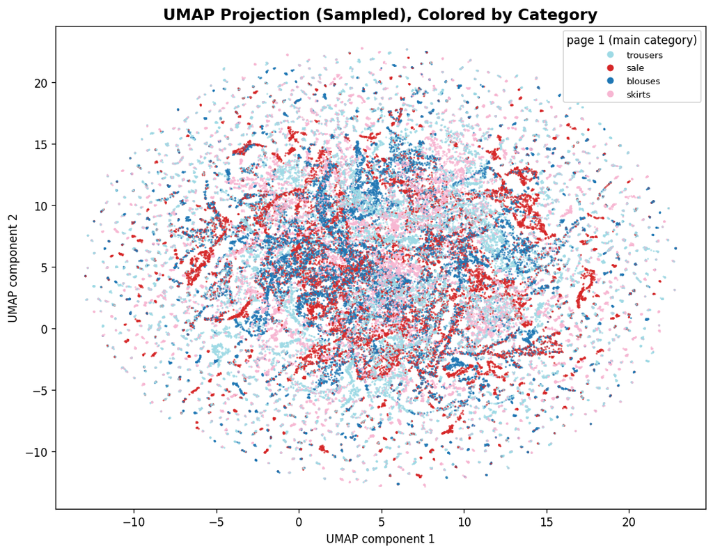

```python
import matplotlib.pyplot as plt

hue = df.loc[idx_plot, CATEGORY_COL].astype("category")
codes = hue.cat.codes.to_numpy()
cmap = plt.cm.get_cmap("tab20", int(hue.cat.categories.size))

plt.figure(figsize=(9, 7), dpi=120)
plt.scatter(
    embedding[:, 0], embedding[:, 1],
    c=codes, cmap=cmap,
    s=3, alpha=0.75, rasterized=True, linewidths=0
)

# Add compact legend for top 15 categories
vc = hue.value_counts().head(15)
handles, labels = [], []
for cat in vc.index:
    i = int(hue.cat.categories.get_loc(cat))
    handles.append(plt.Line2D([0], [0], marker='o', linestyle='',
                              markerfacecolor=cmap(i), markeredgecolor='none', markersize=6))
    labels.append(str(cat))
if handles:
    plt.legend(handles, labels, title=CATEGORY_COL, loc="best", fontsize=8, frameon=True)

plt.title("UMAP Projection (Sampled), Colored by Category", fontsize=14, weight="bold")
plt.xlabel("UMAP component 1")
plt.ylabel("UMAP component 2")
plt.tight_layout()
plt.show()
```

The UMAP projection shows that the numeric features present in our dataset (price, order patterns, etc.) form continuous gradients rather than discrete, well-separated clusters. The overlap between categories is substantial, indicating that these groups are not easily distinguishable by numeric features alone. Predictably (unlike other categories), the “sale” category is scattered broadly, which is expected due to its application across multiple product types.

Customer behavior across categories is numerically similar, meaning product differentiation will require richer attributes (e.g., style, material, demographics). However, some localized clusters indicate the possibility of category-specific groups that may exist (For examplpe, groups of lower-priced trousers).

## References

[1] UCI Machine Learning Repository. Clickstream Data for Online Shopping. https://archive.ics.uci.edu/dataset/553/clickstream+data+for+online+shopping (Accessed 09-14-2025)

[2] Łapczyński M., Białowąs S. (2013). Discovering Patterns of Users' Behaviour in an E-shop – Comparison of Consumer Buying Behaviours in Poland and Other European Countries. *Studia Ekonomiczne*, nr 151, “La société de l'information : perspective européenne et globale : les usages et les risques d'Internet pour les citoyens et les consommateurs”, pp. 144–153.